# Part II - Features that affect Borrower's Interest Rate on Loans

## by (Olatunji Titobiloluwa)

## Investigation Overview

I want to investigate the features that have major effect on a Borrower's interest Rate which are Original Loan Amount and Prosper Ratings.

## Dataset Overview

This data set contains 113,937 loans with 81 variables on each loan, including loan amount, borrower rate (or interest rate), current loan status, borrower income, and many others. There are three ordered categorical variables namely : Prosper Ratings, Prosper Score and Employment Status. After removing missing loan records (wrangling ), we have a total of 84,853 loans that we made use of for this exploration project.

## Distribution of Borrower Rate

The distribution of Borrower's rate is roughly multimodal with a small peak at 0.1 and a large peak a little after 0.15. We also have another small peak at 0.20 then another at almost 0.30. Additionally, we have a very sharp peak at approximately 0.32 and then another slight jump right before 0.35.

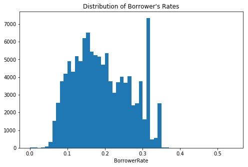

## Distribution of Original Loan Amount

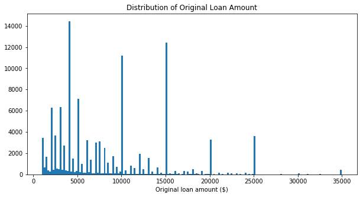

## Effect of Original Loan Amount on Borrower's Rate

There is a negative correlation between BorrowerRate and LoanOriginalAmount which disagrees with my hypothesis: the higher the loan amount, the higher the interest rate. From the plot, it shows that the higher the loan amount, the lower the interest rate and lower loan amounts yields higher interest rates.

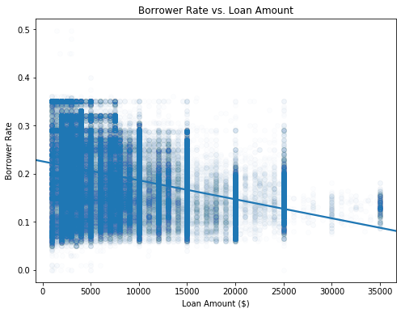

## Effect of Prosper Ratings on Borrower's Rate

The BorrowerRate decreases with better ratings. Borrowers with the best ratings have the lowest interest rate. This shows that Prosper Ratings has a strong effect on Borrower's interest rate.

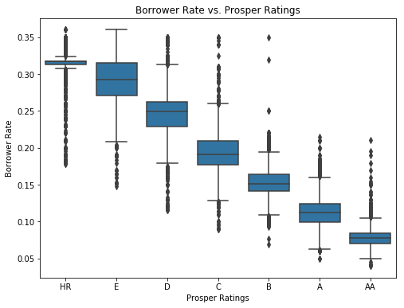